# Trabajo Práctico: Árboles de Clasificación y Regresión

Autores/as

Afiliación

Miguel Garrone

Universidad Austral

Lucía Tamplin

Milagros Terán

Martín Ceriotti

# Análisis descriptivo de los datos

Para comenzar el análisis, se observaron algunas variables de interés y se convirtieron a factores aquellas que podían utilizarse para luego crear un Árbol de Clasificación y Regresión.

Como primer paso, se decidió observar el género de los pasajeros y, además, se observó esta misma variable según la variable “Survived”. La misma indica si el pasajero falleció en el accidente o no.

```
female   male
   314    577
```

```
     Murio Sobrevivio
       549        342
```

```
             female male
  Murio          81  468
  Sobrevivio    233  109
```

En segundo lugar, se decidió observar la distribución de la variable “Age” la cual indica la edad de los pasajeros. Además, se realizó la imputación de los valores faltantes por el valor mediano (Mediana = 28,00 años).

```
   Min. 1st Qu.  Median    Mean 3rd Qu.    Max.    NA's
   0.42   20.12   28.00   29.70   38.00   80.00     177
```

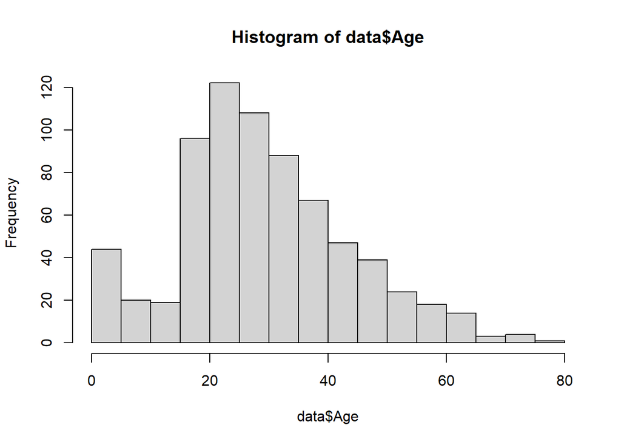

Además, se observó la distribución de las tarifas y resultó de interés observar el/la pasajero/a que tenía el valor máximo de esta variable.

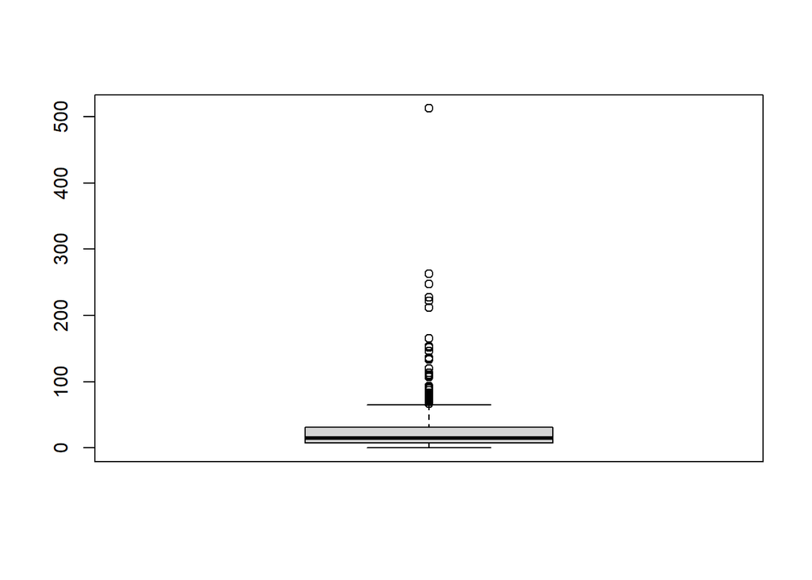

```
[1] 259
```

```
# A tibble: 1 × 11
  Survived   Pclass Name     Sex     Age SibSp Parch Ticket  Fare Cabin Embarked
  <fct>      <ord>  <chr>    <chr> <dbl> <dbl> <dbl> <chr>  <dbl> <chr> <chr>
1 Sobrevivio 1      Ward, M… fema…    35     0     0 PC 17…  512. <NA>  C
```

# Árboles de Clasificación y Regresión

Para realizar el modelo, se decidió utilizar el 80% de los datos como entrenamiento y el 20% restante se utilizó para probar la exactitud del modelo.

Como primer paso, se decidió realizar un árbol con la variable “Sex” para poder interpretarlo de manera simple. A continuación, se puede observar el gráfico:

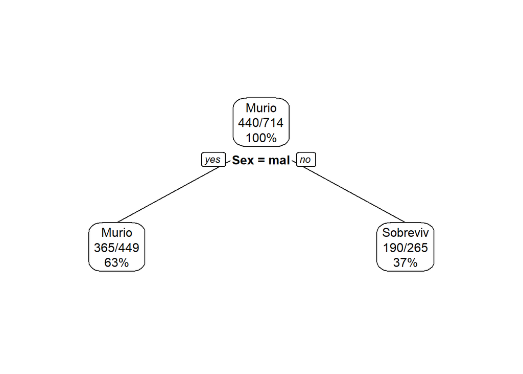

En el gráfico se puede observar que se tiene un total de 714 pasajeros, de los cuales 440 han fallecido. Además, se puede ver que 365 de los pasajeros que murieron eran del género masculino y 75 eran del género femenino. Sin embargo, del total de pasajeros, el 63% eran hombres y 37% mujeres.

Por último, se decidió realizar un modelo más complejo, teniendo en cuenta el género, la clase, la tarifa y la edad de los pasajeros.

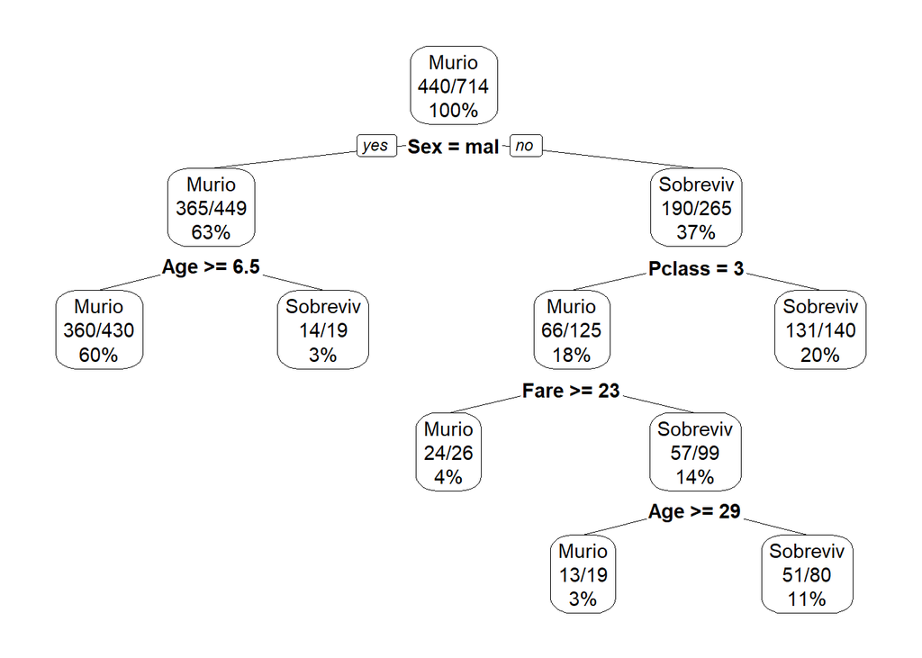

```
Classification tree:
rpart(formula = Survived ~ Sex + Pclass + Fare + Age, data = train_data,
    cp = 0.015)

Variables actually used in tree construction:
[1] Age    Fare   Pclass Sex

Root node error: 274/714 = 0.38375

n= 714

        CP nsplit rel error  xerror     xstd
1 0.419708      0   1.00000 1.00000 0.047424
2 0.040146      1   0.58029 0.58029 0.040574
3 0.032847      3   0.50000 0.55109 0.039824
4 0.025547      4   0.46715 0.51095 0.038719
5 0.015000      5   0.44161 0.49270 0.038186
```

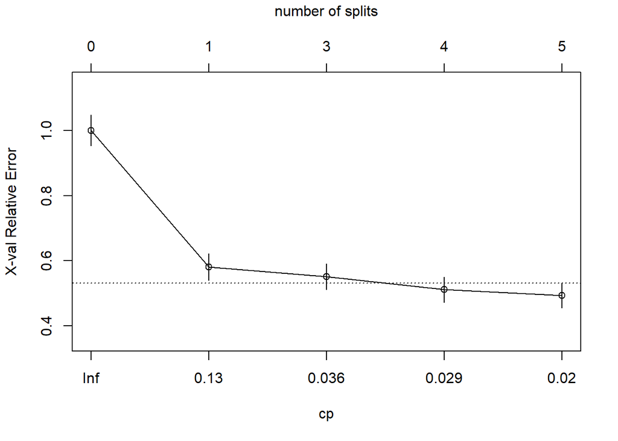

Las salidas anteriores presentan:

- El error de cross-validation vs. tamaño del árbol.
- El punto donde el árbol deja de mejorar.

A continuación, se realizan las predicciones del modelo elegido:

```
Confusion Matrix and Statistics

            Reference
Prediction   Murio Sobrevivio
  Murio        100         26
  Sobrevivio     9         42

               Accuracy : 0.8023
                 95% CI : (0.7359, 0.8582)
    No Information Rate : 0.6158
    P-Value [Acc > NIR] : 7.432e-08

                  Kappa : 0.5615

 Mcnemar's Test P-Value : 0.006841

            Sensitivity : 0.9174
            Specificity : 0.6176
         Pos Pred Value : 0.7937
         Neg Pred Value : 0.8235
             Prevalence : 0.6158
         Detection Rate : 0.5650
   Detection Prevalence : 0.7119
      Balanced Accuracy : 0.7675

       'Positive' Class : Murio
```

En la salida anterior se puede observar que el modelo tiene una Accuracy de 0.8023 y un coeficiente Kappa de 0.5615.

Accuracy es la proporción de predicciones totales que el modelo realizó correctamente. Mientras que, el Estadístico Kappa de Cohen mide la concordancia entre las predicciones del modelo y la verdad real, después de excluir la concordancia que se esperaría que ocurriera aleatoriamente.

Como último paso, se realiza la validación cruzada del modelo:

```
CART

714 samples
  4 predictor
  2 classes: 'Murio', 'Sobrevivio'

No pre-processing
Resampling: Cross-Validated (10 fold, repeated 2 times)
Summary of sample sizes: 642, 643, 643, 643, 643, 642, ...
Resampling results:

  Accuracy   Kappa
  0.7947183  0.5560575

Tuning parameter 'cp' was held constant at a value of 0.015
```

En la salida anterior, se observa un 79% de Accuracy lo cual resulta razonable y no estaría indicando sobreajuste fuerte. Además con este valor, podemos decir que el CP seleccionado parece razonable. Por lo tanto, con la validación cruzada se puede concluir que el modelo es confiable.